# Homework 6

### Exercise 10.49

```r
data("CreditRisk")

# Remove NAs
CreditRisk <- CreditRisk %>%
 na.omit()

# Create Model
mod2 <- glm(Overdrawn~Age+Sex+DaysDrink, CreditRisk, family = "binomial")
summary(mod2)
```

```
##
## Call:
## glm(formula = Overdrawn ~ Age + Sex + DaysDrink, family = "binomial",
##     data = CreditRisk)
##
## Deviance Residuals:
##     Min       1Q   Median       3Q      Max
## -1.5378  -0.5598  -0.4404  -0.2868   2.5874
##
## Coefficients:
##             Estimate Std. Error z value Pr(>|z|)
## (Intercept) -8.19320    1.99001  -4.117 3.84e-05 ***
## Age          0.24949    0.09580   2.604 0.009205 **
## Sex          1.25477    0.34788   3.607 0.000310 ***
## DaysDrink    0.07068    0.01821   3.881 0.000104 ***
## ---
## Signif. codes:  0 '***' 0.001 '**' 0.01 '*' 0.05 '.' 0.1 ' ' 1
##
## (Dispersion parameter for binomial family taken to be 1)
##
##     Null deviance: 334.61  on 436  degrees of freedom
## Residual deviance: 306.06  on 433  degrees of freedom
## AIC: 314.06
##
## Number of Fisher Scoring iterations: 5
```

```r
# Evaluate Coefficients
exp(coef(mod2))
```

```
##  (Intercept)          Age          Sex    DaysDrink
## 0.0002765278 1.2833751984 3.5070280313 1.0732395080
```

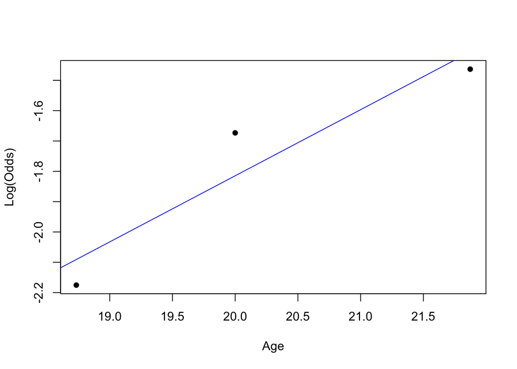

```r
# Check Assumptions
emplogitplot1(Overdrawn~Age, CreditRisk)
```

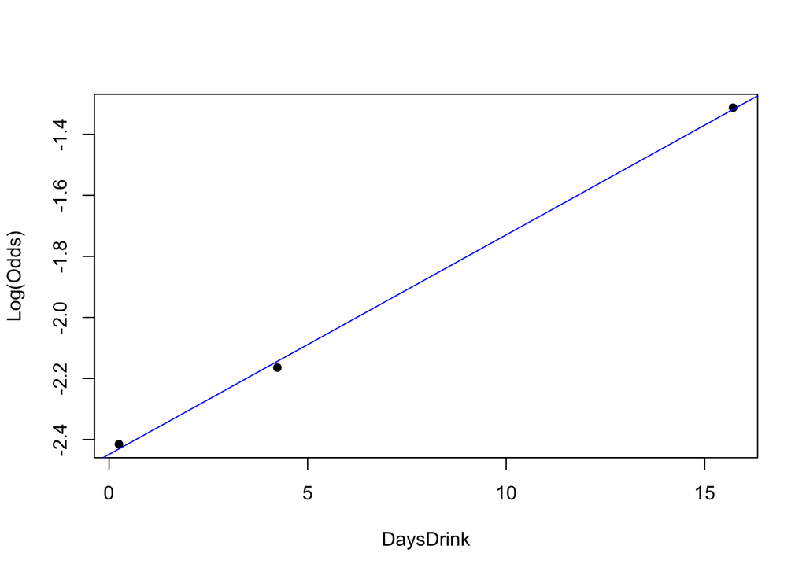

```r
emplogitplot1(Overdrawn~DaysDrink, CreditRisk)
```

To start, rows with missing values were removed from the dataset to make the model building more accurate. Older students, female students and students with a greater frequency of alcoholic consumption were significantly more likely to have overdrawn their checking account. Each additional increase in age from the age of 18 increased the odds of overdrawing by 1.28, while being a woman increased the odds by 3.51. Each additional day drinking in the last 30 days increased the odds of overdrawing by 1.07. Since all these variables have a p-value of <0.05 in the model, they have a significant relationship with Overdrawing. Checking that the assumptions for logistic inferences are met, both logit plots appear to display linearity for the two explanatory variables. The survey format means however that the randomness assumption is not met, and independence of responses can be assumed to be true.